# BellaBeat Case Study

Oscar (Hong-Jyun) Wang

2025-09-07

# Business Scenario

Bellabeat, a high-tech company that manufactures health-focused smart products for women. Bellabeat wants to become a larger player in the global smart device market. As a data analyst, I am asked to analyse smart device data to gain insight into how consumers are using their smart devices. The insights will then help guide marketing strategy for the company.

# Business Task

Identify the potential trends and inform the marketing strategy, and gain insight into how consumers use non-Bellabeat smart devices.

**1. What are some trends in smart device usage?**

**2. How could these trends help influence Bellabeat marketing strategy?**

# Data Preparation and Cleaning

First, dataset is cleaned and prepared by converting data types, filtering useful info, and deleting irrelevant fields.

```r
#Data Cleaning for Activity Dataset
activity <- read.csv("dailyActivity_merged.csv")
activity <- activity %>%
    mutate(ActivityDate = mdy(ActivityDate),
           Weekdays = wday(ActivityDate, label = TRUE, abbr = FALSE),
           Id = as.character(Id)) %>%
    select(-LoggedActivitiesDistance,
           -SedentaryActiveDistance) %>%
    filter(TotalSteps > 0,
           SedentaryMinutes > 0,
           Calories > 0)
```

# Data Analysis

### Analysis 1 - Understanding of User Types

**The goal is to gain an understanding of the user types based on daily walking steps.**

Users are catogorised based on their daily steps to **understand the proportions of smart device users**, where users with daily steps less than 3000 are regarded as less, between 3000 to 6000 as normal, between 6000 to 10000 as healthy, and over 10000 steps as very healthy. Afterwards, calculate the user proportions based on their activity type, and visualise the proportions.

```r
#Data Analysis - Categorise the Smart Device Users
user_summary <- activity %>%
    group_by(Id) %>%
    summarize(TotalSteps = mean(TotalSteps, na.rm = TRUE),
              SedentaryMinutes = mean(SedentaryMinutes, na.rm = TRUE),
              Calories = mean(Calories, na.rm = TRUE)) %>%
    mutate(ActiveType = case_when(
        TotalSteps <= 3000 ~ "Less",
        TotalSteps <= 6000 ~ "Normal",
        TotalSteps <= 10000 ~ "Healthy",
        TRUE ~ "VeryHealthy"))
```

```r
#Create a User Proportion Table
library(gt)
user_proportion <- user_summary %>%
    group_by(ActiveType) %>%
    count() %>%
    mutate(proportion = n/34,
           ActiveType = factor(ActiveType,
                               levels = c("Less", "Normal", "Healthy", "VeryHealthy")),
           percentage = paste0(round(proportion * 100, 1), "%")) %>%
    arrange(ActiveType)

user_proportion
```

```
## # A tibble: 4 × 4
## # Groups:   ActiveType [4]
##   ActiveType      n proportion percentage
##   <fct>       <int>      <dbl> <chr>
## 1 Less            1     0.0294 2.9%
## 2 Normal         13     0.382  38.2%
## 3 Healthy        12     0.353  35.3%
## 4 VeryHealthy     8     0.235  23.5%
```

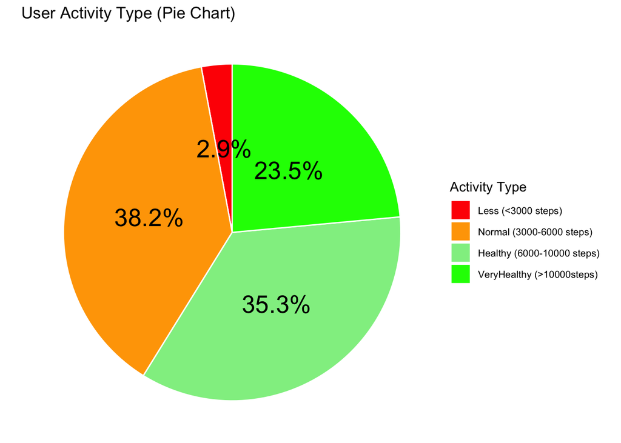

```r
#Create a Pie Chart for User Active Type
ggplot(data = user_proportion, mapping = aes(x="", y=proportion, fill=ActiveType))+
    geom_col(width = 1, color = 'white')+
    coord_polar(theta = "y")+
    labs(title = "User Activity Type (Pie Chart)")+
    geom_text(aes(label = percentage),
              position = position_stack(vjust = 0.5), size = 7)+
    theme_void()+
    scale_fill_manual(values = c("Less" = "red",
                                 "Normal" = "orange",
                                 "Healthy" = "lightgreen",
                                 "VeryHealthy" = "green"),
                      labels = c("Less" = "Less (<3000 steps)",
                                 "Normal" = "Normal (3000-6000 steps)",
                                 "Healthy" = "Healthy (6000-10000 steps)",
                                 "VeryHealthy" = "VeryHealthy (>10000steps)"))+
    guides(fill = guide_legend(title = "Activity Type"))+
    theme(legend.text = element_text(size = 8))  # increase font size if needed
```

### Analysis 2 - Observe the Activity Trends

**The goal here is to understand how to implement the marketing strategies to potential users.**

Firstly, daily steps of users are analysed in detail to check **which day people walk most frequently.** Afterwards, **daily steps are aggregated and converted to find the time people walk the most.** These two info will inform Bellabeat regarding the advertisement.

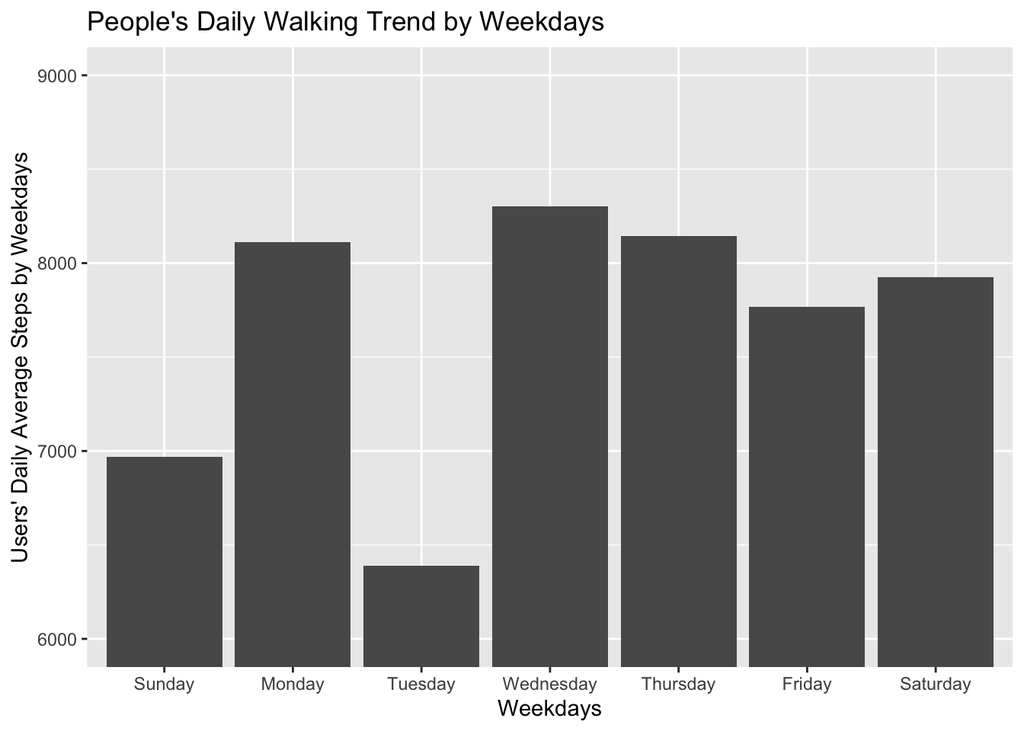

```r
#Data Analysis - Looking for Weekdays Walking Trends

weekdays_steps <- activity %>%
    group_by(Id, Weekdays) %>%
    summarize(UserWeekdaySteps = mean(TotalSteps)) %>%
    ungroup() %>%
    group_by(Weekdays) %>%
    summarize(WeekdaySteps = mean(UserWeekdaySteps))

ggplot(data = weekdays_steps)+
    geom_col(aes(x=Weekdays, y=WeekdaySteps))+
    coord_cartesian(ylim = c(6000, 9000))+
    labs(title = "People's Daily Walking Trend by Weekdays",
         y = "Users' Daily Average Steps by Weekdays")
```

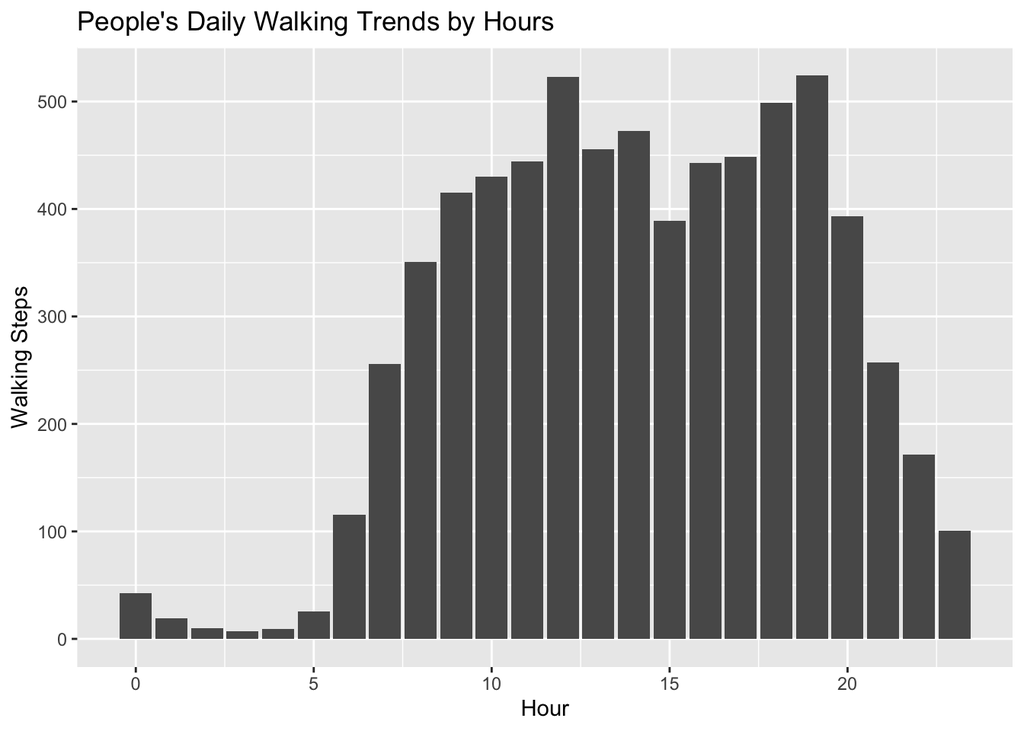

```r
#Data Analysis - Looking for Hourly Walking Trends
hr_steps <- read.csv("hourlySteps_merged.csv")
hr_steps <- hr_steps %>%
    mutate(ActivityHour = floor_date(mdy_hms(ActivityHour), unit = "hour"),
           Hour = hour(ActivityHour),
           Id = as.character(Id))
steps_sum <- hr_steps %>%
    group_by(Id, Hour) %>%
    summarize(UserHourlySteps = mean(StepTotal)) %>%
    ungroup() %>%
    group_by(Hour) %>%
    summarize(HourlySteps = mean(UserHourlySteps))

ggplot(data = steps_sum)+
    geom_col(mapping = aes(x = Hour, y = HourlySteps))+
    labs(title = "People's Daily Walking Trends by Hours",
         y = "Walking Steps")
```

# Result

# Recommendations

### 1. Marketing Strategy - Targeting the Right Audience

From user analysis, around 73% of the smart device users take a stroll with 3000 to 10000 steps every day, meaning these users have moderately daily physical activities. Compared to sedentary individuals (daily steps < 3000) or habitual exercisers (daily steps > 10000), the users deserve better attention, whose characteristics and habits are different and require tailored marketing strategies. For example, these users typically want to maintain healthy habits under limited resources (e.g. time), so providing smart device that tracks daily steps can be attractive to them.